# Count Regression (ELMR Chapter 5)

Biostat 200C

Author

Dr. Jin Zhou @ UCLA

Published

April 30, 2024

Display system information and load `tidyverse` and `faraway` packages

```r
library(tidyverse)
library(faraway)
```

`faraway` package contains the datasets in the ELMR book.

## 1 Galápagos data

The `gala` data set records the number of plant species and the number of endemic species for 30 Galápagos islands. We are interested in modeling the number of species using a regression.

[figure not shown]

[figure not shown]

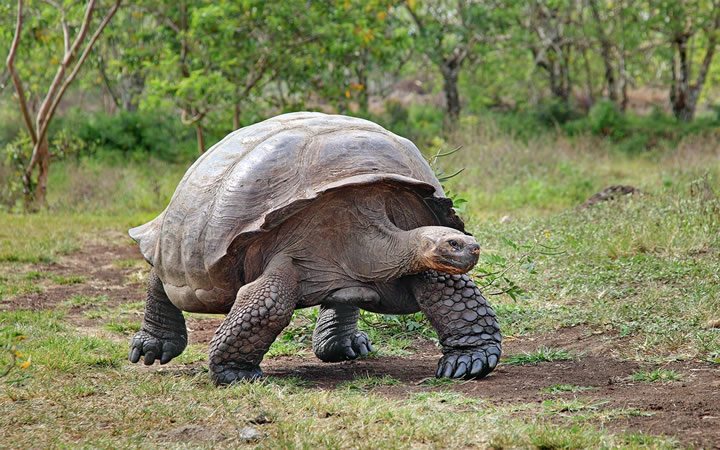

```r
gala <- as_tibble(gala, rownames = "Island") %>%
  print(n = Inf)
```

```
# A tibble: 30 × 8
   Island       Species Endemics    Area Elevation Nearest Scruz Adjacent
   <chr>          <dbl>    <dbl>   <dbl>     <dbl>   <dbl> <dbl>    <dbl>
 1 Baltra            58       23   25.1        346     0.6   0.6     1.84
 2 Bartolome         31       21    1.24       109     0.6  26.3   572.
 3 Caldwell           3        3    0.21       114     2.8  58.7     0.78
 4 Champion          25        9    0.1         46     1.9  47.4     0.18
 5 Coamano            2        1    0.05        77     1.9   1.9   904.
 6 Daphne.Major      18       11    0.34       119     8     8       1.84
 7 Daphne.Minor      24        0    0.08        93     6    12       0.34
 8 Darwin            10        7    2.33       168    34.1 290.      2.85
 9 Eden               8        4    0.03        71     0.4   0.4    18.0
10 Enderby            2        2    0.18       112     2.6  50.2     0.1
11 Espanola          97       26   58.3        198     1.1  88.3     0.57
12 Fernandina        93       35  634.        1494     4.3  95.3  4669.
```

[output cut: 18 more lines]

A histogram of the number of species

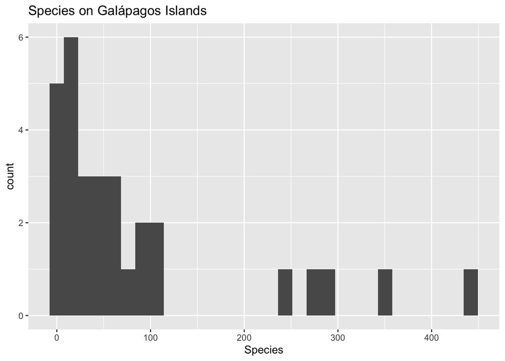

```r
gala %>%
  ggplot() +
  geom_histogram(mapping = aes(x = Species)) +
  labs(title = "Species on Galápagos Islands")
```

## 2 Poisson regession

- Assume the count response $Y_i$ follows a Poisson$(\mu_i)$ distribution with density function
  $$\mathbb{P}(Y_i = y_i) = e^{-\mu_i} \frac{\mu_i^{y_i}}{y_i!}.$$
- The Poisson parameter $\mu_i$ is related to the predictors via an **inverse link function**
  $$\mu_i = e^{\eta_i},$$
  where $\eta_i$ is the **linear predictor** or **systematic component**
  $$\eta_i = \mathbf{x}_i^T \boldsymbol{\beta}.$$
- The function
  $$\eta_i = g(\mu_i) = \log \mu_i$$
  that links $\mathbb{E} Y_i = \mu_i$ to the systematic component is called the **link function**. This particular link function is called the **log link function**. The Poisson regression model with log link is also called a **log-linear model**.
- Given the $n$ independent data points $(y_i, \mathbf{x}_i)$, $i=1,\ldots,n$, the log-likelihood is
  $$\begin{eqnarray*}
  \ell(\boldsymbol{\beta}) &=& \sum_i y_i \log \mu_i - \mu_i - \log y_i! \\
  &=& \sum_i y_i \cdot \mathbf{x}_i^T \boldsymbol{\beta} - e^{\mathbf{x}_i^T \boldsymbol{\beta}} - \log y_i!
  \end{eqnarray*}$$
- We maximize the log-likelihood function to find the MLE of regression coefficient $\boldsymbol{\beta}$.

```r
modp <- glm(Species ~ . - Endemics - Island, family = poisson, data = gala)
summary(modp)
```

```
Call:
glm(formula = Species ~ . - Endemics - Island, family = poisson,
    data = gala)

Coefficients:
              Estimate Std. Error z value Pr(>|z|)
(Intercept)  3.155e+00  5.175e-02  60.963  < 2e-16 ***
Area        -5.799e-04  2.627e-05 -22.074  < 2e-16 ***
Elevation    3.541e-03  8.741e-05  40.507  < 2e-16 ***
Nearest      8.826e-03  1.821e-03   4.846 1.26e-06 ***
Scruz       -5.709e-03  6.256e-04  -9.126  < 2e-16 ***
Adjacent    -6.630e-04  2.933e-05 -22.608  < 2e-16 ***
---
Signif. codes:  0 '***' 0.001 '**' 0.01 '*' 0.05 '.' 0.1 ' ' 1

(Dispersion parameter for poisson family taken to be 1)

    Null deviance: 3510.73  on 29  degrees of freedom
Residual deviance:  716.85  on 24  degrees of freedom
AIC: 889.68

Number of Fisher Scoring iterations: 5
```

## 3 Interpretation

- Regression coefficients reflect the unit change in the log of Poisson mean.

```r
library(gtsummary)
modp %>%
  tbl_regression(intercept = TRUE)
```

| **Characteristic** | **log(IRR)**<sup>1</sup> | **95% CI**<sup>1</sup> | **p-value** |
| --- | --- | --- | --- |
| (Intercept) | 3.2 | 3.1, 3.3 | <0.001 |
| Area | 0.00 | 0.00, 0.00 | <0.001 |
| Elevation | 0.00 | 0.00, 0.00 | <0.001 |
| Nearest | 0.01 | 0.01, 0.01 | <0.001 |
| Scruz | -0.01 | -0.01, 0.00 | <0.001 |
| Adjacent | 0.00 | 0.00, 0.00 | <0.001 |

<sup>1</sup> IRR = Incidence Rate Ratio, CI = Confidence Interval

```r
modp %>%
  tbl_regression(intercept = TRUE, exponentiate = TRUE)
```

| **Characteristic** | **IRR**<sup>1</sup> | **95% CI**<sup>1</sup> | **p-value** |
| --- | --- | --- | --- |
| (Intercept) | 23.4 | 21.2, 25.9 | <0.001 |
| Area | 1.00 | 1.00, 1.00 | <0.001 |
| Elevation | 1.00 | 1.00, 1.00 | <0.001 |
| Nearest | 1.01 | 1.01, 1.01 | <0.001 |
| Scruz | 0.99 | 0.99, 1.00 | <0.001 |
| Adjacent | 1.00 | 1.00, 1.00 | <0.001 |

<sup>1</sup> IRR = Incidence Rate Ratio, CI = Confidence Interval

## 4 Goodness of fit

- The deviance for the Poisson regression is
  $$\begin{eqnarray*}
  D &=& 2 \sum_i [y_i \log(y_i) - y_i] - 2 \sum_i [y_i \log (\widehat{\mu}_i) - \widehat{\mu}_i] \\
  &=& 2 \sum_i [y_i \log(y_i / \widehat{\mu}_i) - (y_i - \widehat{\mu}_i)],
  \end{eqnarray*}$$
  where $\widehat{\mu}_i$ are the fitted values from the model. The Poisson deviance is also called the **G-statistic**.
- For the Galápagos example, comparing the deviance $D$ to $\chi_{n - p}^2$ gives an extremely small p-value (why?), indicating a lack of fit.
- An alternative goodness of fit test compares the **Pearson $X^2$**
  $$X^2 = \sum_i \frac{(O_i - E_i)^2}{E_i} = \sum_i \frac{(y_i - \widehat{\mu}_i)^2}{\widehat{\mu}_i}$$
  to the asymptotic distribution $\chi_{n - p}^2$. Again it indicates serious lack of fit.

```r
# predmu = predict(modp, type = "response")
# sum((gala$Species - predmu)^2 / predmu)
(px2 <- sum(residuals(modp, type = "pearson")^2))
```

```
[1] 761.9792
```

## 5 Diagnostics

- Plot deviance residuals against linear predictor. We don’t see outliers.

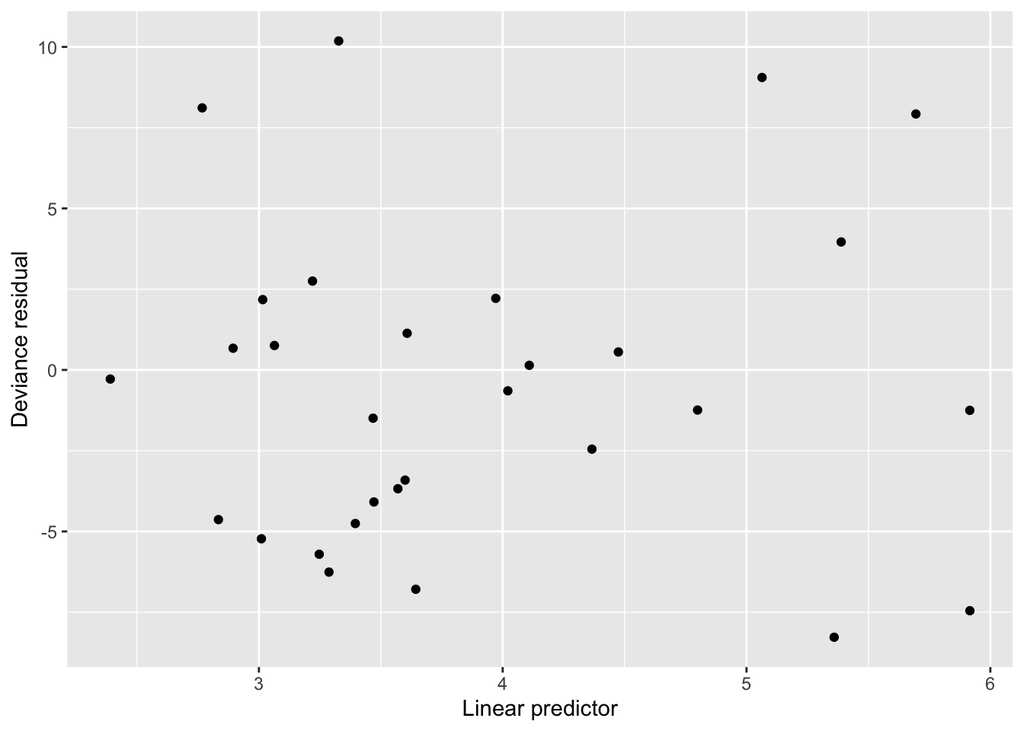

```r
gala %>%
  mutate(devres  = residuals(modp, type = "deviance"),
         linpred = predict(modp, type = "link")) %>%
  ggplot +
  geom_point(mapping = aes(x = linpred, y = devres)) +
  labs(x = "Linear predictor", y = "Deviance residual")
```

- Plot Pearson residuals against linear predictor. We don’t see outliers.

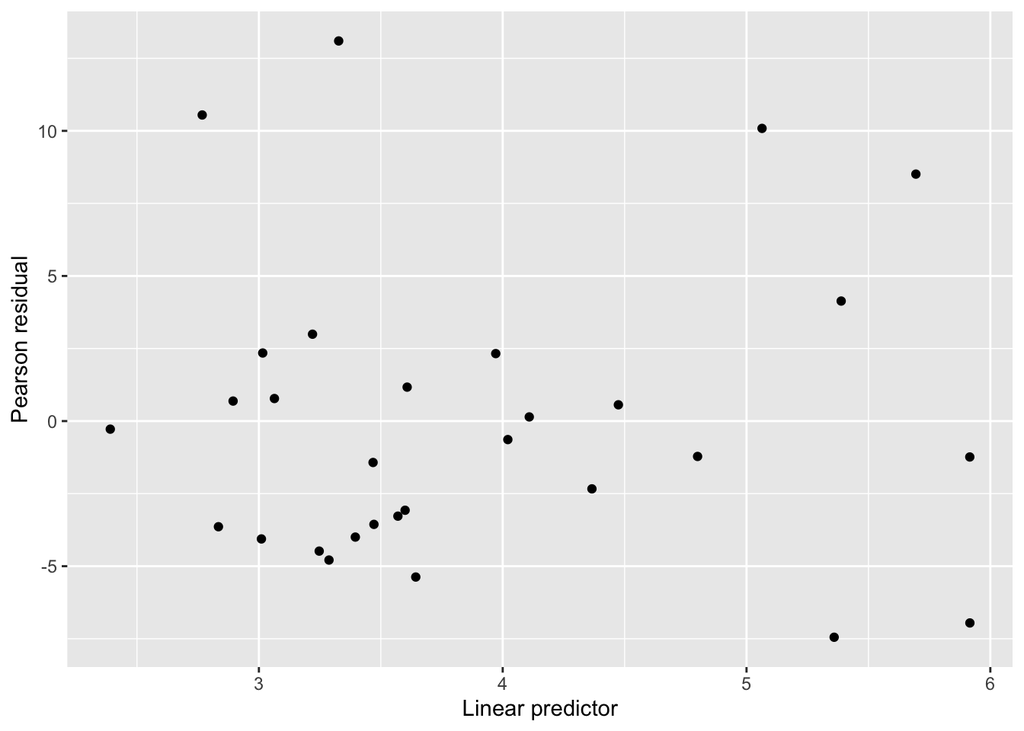

```r
gala %>%
  mutate(perres  = residuals(modp, type = "pearson"),
         linpred = predict(modp, type = "link")) %>%
  ggplot +
  geom_point(mapping = aes(x = linpred, y = perres)) +
  labs(x = "Linear predictor", y = "Pearson residual")
```

- Any high leverage points? `Fernandina` and `Isabela` islands have high elevation and relatively large area.

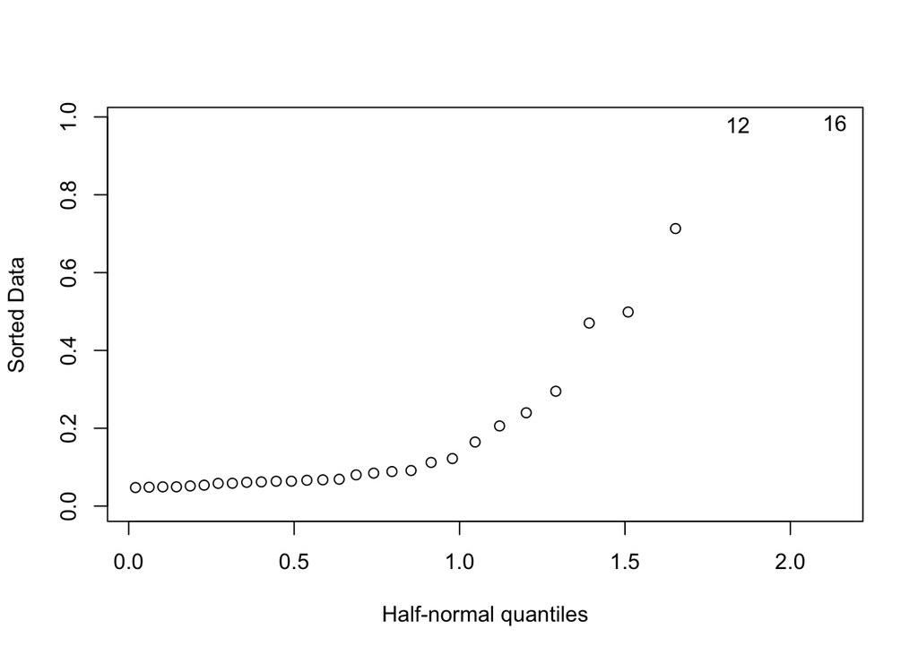

```r
halfnorm(hatvalues(modp))
```

```r
gala %>%
  slice(c(12, 16))
```

```
# A tibble: 2 × 8
  Island     Species Endemics  Area Elevation Nearest Scruz Adjacent
  <chr>        <dbl>    <dbl> <dbl>     <dbl>   <dbl> <dbl>    <dbl>
1 Fernandina      93       35  634.      1494     4.3  95.3    4669.
2 Isabela        347       89 4669.      1707     0.7  28.1     634.
```

- Any high influential points?

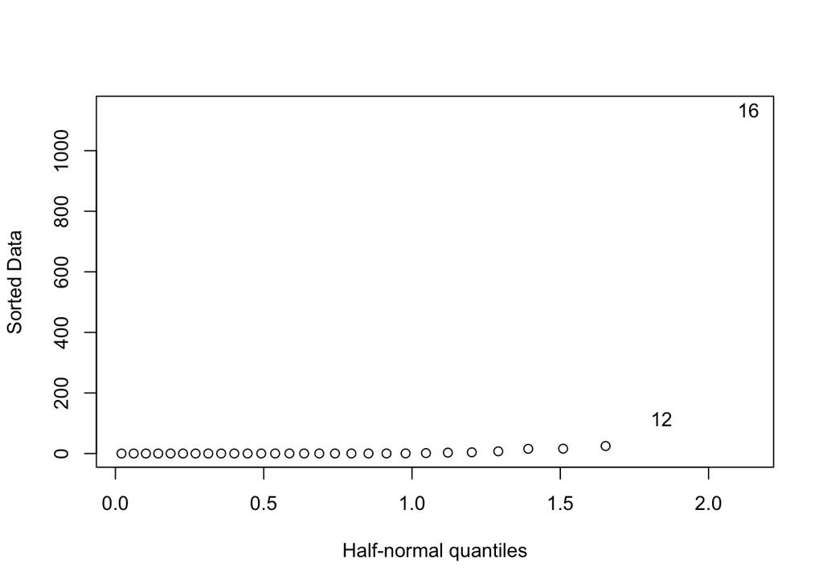

```r
halfnorm(cooks.distance((modp)))
```

- For Poisson distribution, $\mathbb{E}Y_i = \operatorname{Var}Y_i = \mu_i$. Let’s check this assumption. We use $(y_i - \widehat{\mu}_i)^2$ as a crude estimate of $\operatorname{Var}Y_i$. Majority of points are above the 45 degree line. Looks like we have overdispersion.

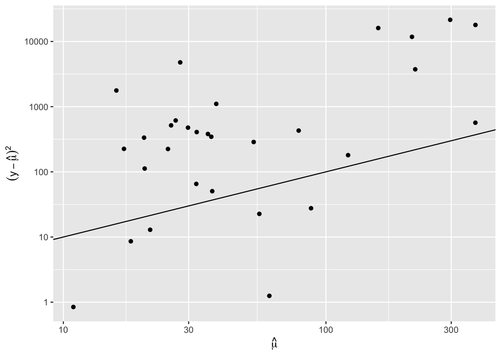

```r
gala %>%
  mutate(predmu = predict(modp, type = "response"),
         res    = Species - predmu) %>%
  ggplot() +
  geom_point(mapping = aes(x = predmu, y = res^2)) +
  geom_abline(intercept = 0, slope = 1) +
  labs(x = expression(hat(mu)), y = expression((y - hat(mu))^2)) +
  scale_x_log10() +
  scale_y_log10()
```

## 6 Overdispersion

- In **overdispersion model**, we assume an **overdispersion parameter** $\phi$ such that
  $$\operatorname{Var} Y_i = \phi \mu_i.$$
- Given MLE, the overdispersion parameter is estimated by
  $$\widehat{\phi} = \frac{X^2}{n - p}.$$

```r
(dp <- px2 / modp$df.residual)
```

```
[1] 31.74914
```

- The inference on regression coefficient is changed with overdispersion parameter. We see predictors `Area`, `Elevation` and `Adjacent` are significant, but not `Nearest` and `Scruz`.

```r
summary(modp, dispersion = dp)
```

```
Call:
glm(formula = Species ~ . - Endemics - Island, family = poisson,
    data = gala)

Coefficients:
              Estimate Std. Error z value Pr(>|z|)
(Intercept)  3.1548079  0.2915897  10.819  < 2e-16 ***
Area        -0.0005799  0.0001480  -3.918 8.95e-05 ***
Elevation    0.0035406  0.0004925   7.189 6.53e-13 ***
Nearest      0.0088256  0.0102621   0.860    0.390
Scruz       -0.0057094  0.0035251  -1.620    0.105
Adjacent    -0.0006630  0.0001653  -4.012 6.01e-05 ***
---
Signif. codes:  0 '***' 0.001 '**' 0.01 '*' 0.05 '.' 0.1 ' ' 1

(Dispersion parameter for poisson family taken to be 31.74914)

    Null deviance: 3510.73  on 29  degrees of freedom
Residual deviance:  716.85  on 24  degrees of freedom
AIC: 889.68

Number of Fisher Scoring iterations: 5
```

```r
drop1(modp, scale = dp, test = "F")
```

```
Single term deletions

Model:
Species ~ (Island + Endemics + Area + Elevation + Nearest + Scruz +
    Adjacent) - Endemics - Island

scale:  31.74914

          Df Deviance    AIC F value    Pr(>F)
<none>         716.85 889.68
Area       1  1204.35 903.03 16.3217 0.0004762 ***
Elevation  1  2389.57 940.36 56.0028 1.007e-07 ***
Nearest    1   739.41 888.39  0.7555 0.3933572
Scruz      1   813.62 890.72  3.2400 0.0844448 .
Adjacent   1  1341.45 907.35 20.9119 0.0001230 ***
---
Signif. codes:  0 '***' 0.001 '**' 0.01 '*' 0.05 '.' 0.1 ' ' 1
```

## 7 Quasi-Poisson

- Quasi-Poisson assumes
  $$\mathbb{E}Y_i = \mu_i, \quad \operatorname{Var}Y_i = \phi \mu_i$$
  only and yields similar inference.

```r
modd <- glm(Species ~ . - Endemics - Island, family = quasipoisson, data = gala)
summary(modd)
```

```
Call:
glm(formula = Species ~ . - Endemics - Island, family = quasipoisson,
    data = gala)

Coefficients:
              Estimate Std. Error t value Pr(>|t|)
(Intercept)  3.1548079  0.2915901  10.819 1.03e-10 ***
Area        -0.0005799  0.0001480  -3.918 0.000649 ***
Elevation    0.0035406  0.0004925   7.189 1.98e-07 ***
Nearest      0.0088256  0.0102622   0.860 0.398292
Scruz       -0.0057094  0.0035251  -1.620 0.118380
Adjacent    -0.0006630  0.0001653  -4.012 0.000511 ***
---
Signif. codes:  0 '***' 0.001 '**' 0.01 '*' 0.05 '.' 0.1 ' ' 1

(Dispersion parameter for quasipoisson family taken to be 31.74921)

    Null deviance: 3510.73  on 29  degrees of freedom
Residual deviance:  716.85  on 24  degrees of freedom
AIC: NA

Number of Fisher Scoring iterations: 5
```

```r
drop1(modd, test = "F")
```

```
Single term deletions

Model:
Species ~ (Island + Endemics + Area + Elevation + Nearest + Scruz +
    Adjacent) - Endemics - Island
          Df Deviance F value    Pr(>F)
<none>         716.85
Area       1  1204.35 16.3217 0.0004762 ***
Elevation  1  2389.57 56.0028 1.007e-07 ***
Nearest    1   739.41  0.7555 0.3933572
Scruz      1   813.62  3.2400 0.0844448 .
Adjacent   1  1341.45 20.9119 0.0001230 ***
---
Signif. codes:  0 '***' 0.001 '**' 0.01 '*' 0.05 '.' 0.1 ' ' 1
```

## 8 Negative bionomial regression

- An alternative to Poisson model is the **negative binomial distribution** with probability mass function
  $$\mathbb{P}(Y = y) = \binom{y + r - 1}{r - 1} (1 - p)^y p^r, \quad y = 0, 1, \ldots$$
  HW3: show $\mathbb{E}Y = \mu = rp / (1 - p)$ and $\operatorname{Var} Y = r p / (1 - p)^2$.

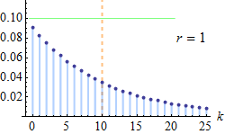

- We can relate mean response $\mu$ to the predictors via log link function
  $$\eta = \mathbf{x}^T \boldsymbol{\beta} = \log \mu.$$
- Pre-specify `r=1` ($\theta$ in MASS) and fit negative bionomial regression:

```r
library(MASS)
modn <- glm(Species ~ . - Endemics - Island, family = negative.binomial(1), data = gala)
summary(modn)
```

```
Call:
glm(formula = Species ~ . - Endemics - Island, family = negative.binomial(1),
    data = gala)

Coefficients:
              Estimate Std. Error t value Pr(>|t|)
(Intercept)  2.9040718  0.2726617  10.651 1.41e-10 ***
Area        -0.0006338  0.0003143  -2.017  0.05506 .
Elevation    0.0038575  0.0007561   5.102 3.21e-05 ***
Nearest      0.0027834  0.0149036   0.187  0.85342
Scruz       -0.0018568  0.0030569  -0.607  0.54929
Adjacent    -0.0007617  0.0002492  -3.057  0.00542 **
---
Signif. codes:  0 '***' 0.001 '**' 0.01 '*' 0.05 '.' 0.1 ' ' 1

(Dispersion parameter for Negative Binomial(1) family taken to be 0.7232273)

    Null deviance: 54.069  on 29  degrees of freedom
Residual deviance: 20.741  on 24  degrees of freedom
AIC: 305.75

Number of Fisher Scoring iterations: 16
```

- Estimate parameter `r` ($\theta$ in MASS) from data:

```r
glm.nb(Species ~ . - Endemics - Island, data = gala) %>%
  summary()
```

```
Call:
glm.nb(formula = Species ~ . - Endemics - Island, data = gala,
    init.theta = 1.674602286, link = log)

Coefficients:
              Estimate Std. Error z value Pr(>|z|)
(Intercept)  2.9065247  0.2510344  11.578  < 2e-16 ***
Area        -0.0006336  0.0002865  -2.211 0.027009 *
Elevation    0.0038551  0.0006916   5.574 2.49e-08 ***
Nearest      0.0028264  0.0136618   0.207 0.836100
Scruz       -0.0018976  0.0028096  -0.675 0.499426
Adjacent    -0.0007605  0.0002278  -3.338 0.000842 ***
---
Signif. codes:  0 '***' 0.001 '**' 0.01 '*' 0.05 '.' 0.1 ' ' 1

(Dispersion parameter for Negative Binomial(1.6746) family taken to be 1)

    Null deviance: 88.431  on 29  degrees of freedom
Residual deviance: 33.196  on 24  degrees of freedom
AIC: 304.22

Number of Fisher Scoring iterations: 1

              Theta:  1.675
          Std. Err.:  0.442

 2 x log-likelihood:  -290.223
```

## 9 Zero-inflated count models

- The `bioChemists` data set contains 915 biochemistry graduate students. The outcome of interest is the number of articles procuded during the last three years of the PhD.

```r
library(pscl)

(bioChemists <- as_tibble(bioChemists))
```

```
# A tibble: 915 × 6
     art fem   mar      kid5   phd  ment
   <int> <fct> <fct>   <dbl> <dbl> <int>
 1     0 Men   Married     0  2.52     7
 2     0 Women Single      0  2.05     6
 3     0 Women Single      0  3.75     6
 4     0 Men   Married     1  1.18     3
 5     0 Women Single      0  3.75    26
 6     0 Women Married     2  3.59     2
 7     0 Women Single      0  3.19     3
 8     0 Men   Married     2  2.96     4
 9     0 Men   Single      0  4.62     6
10     0 Women Married     0  1.25     0
# ℹ 905 more rows
```

- Descriptive statistics.

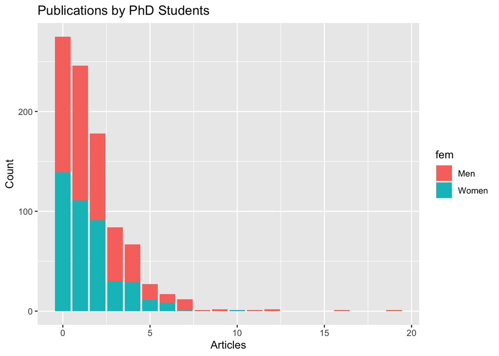

```r
bioChemists %>%
  ggplot() +
  geom_bar(mapping = aes(x = art, fill = fem)) +
  labs(x = "Articles", y = "Count", title = "Publications by PhD Students")
```

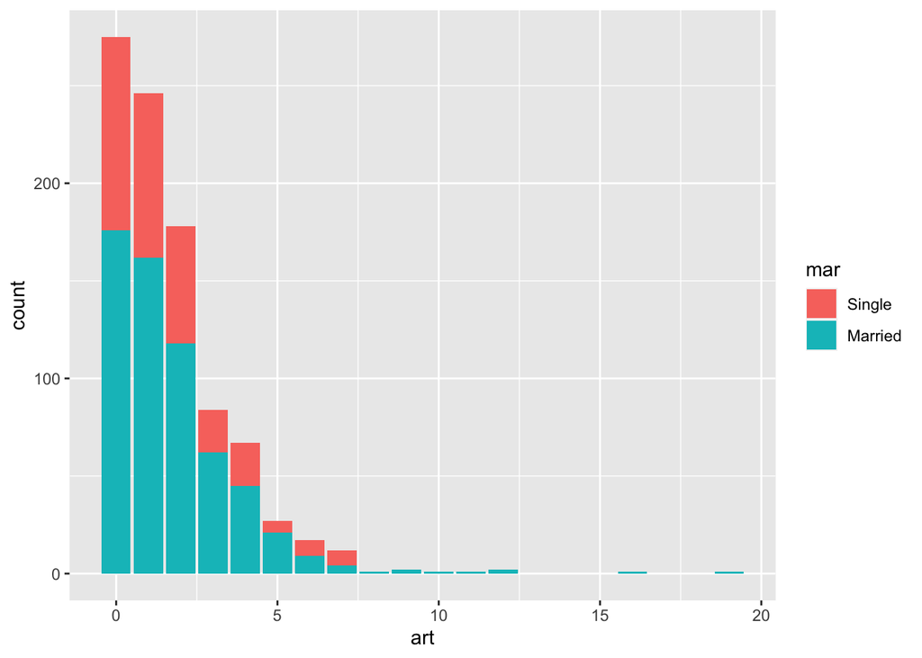

```r
bioChemists %>%
  ggplot() +
  geom_bar(mapping = aes(x = art, fill = mar))
```

- We first fit a Poisson regresison. A deviance of 1634.4 on 909 degrees of freedom indicates a lack of fit.

```r
modp <- glm(art ~ ., family = poisson, data = bioChemists)
summary(modp)
```

```
Call:
glm(formula = art ~ ., family = poisson, data = bioChemists)

Coefficients:
             Estimate Std. Error z value Pr(>|z|)
(Intercept)  0.304617   0.102981   2.958   0.0031 **
femWomen    -0.224594   0.054613  -4.112 3.92e-05 ***
marMarried   0.155243   0.061374   2.529   0.0114 *
kid5        -0.184883   0.040127  -4.607 4.08e-06 ***
phd          0.012823   0.026397   0.486   0.6271
ment         0.025543   0.002006  12.733  < 2e-16 ***
---
Signif. codes:  0 '***' 0.001 '**' 0.01 '*' 0.05 '.' 0.1 ' ' 1

(Dispersion parameter for poisson family taken to be 1)

    Null deviance: 1817.4  on 914  degrees of freedom
Residual deviance: 1634.4  on 909  degrees of freedom
AIC: 3314.1

Number of Fisher Scoring iterations: 5
```

- The observed against fitte values plot shows the prediction for 0 is quite off.

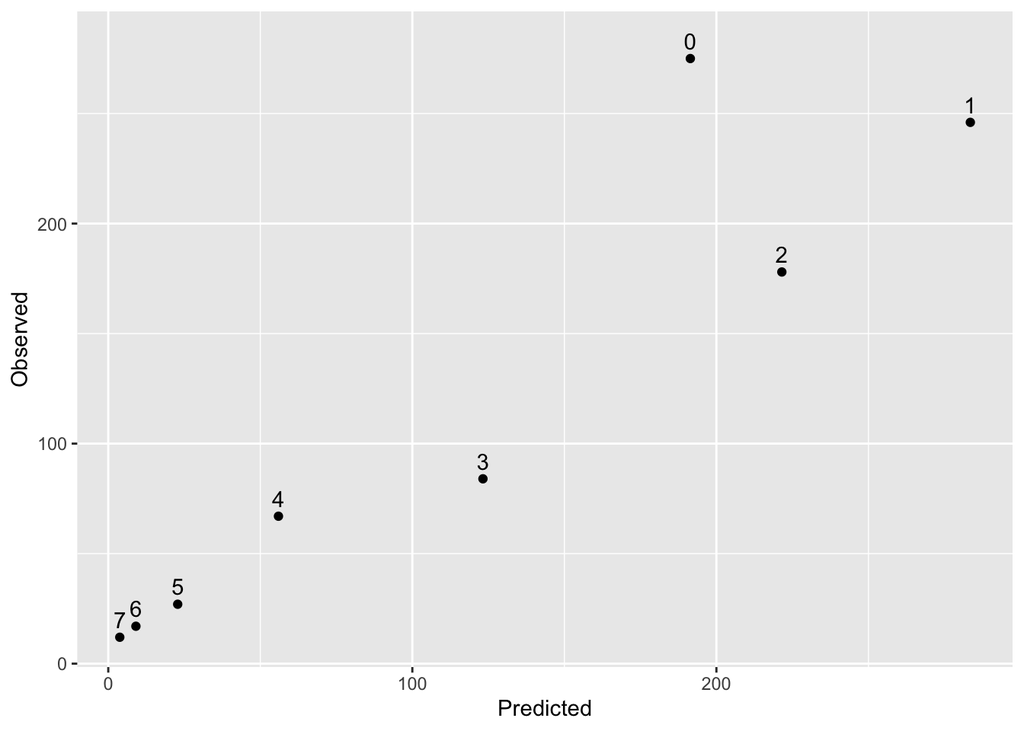

```r
tibble(ocount = table(bioChemists$art)[1:8],    # observed count for 0:7
       pcount = colSums(predprob(modp)[, 1:8]), # expected count for 0:7
       count  = 0:7) %>%
  ggplot(mapping = aes(x = pcount, y = ocount, label = count)) +
  geom_point() +
  geom_text(nudge_y = 8) +
  labs(x = "Predicted", y = "Observed")
```

- The **hurdle model** assumes
  $$\begin{eqnarray*}
  \mathbb{P}(Y = 0) &=& f_1(0), \\
  \mathbb{P}(Y = j) &=& \frac{1 - f_1(0)}{1 - f_2(0)} f_2(j), \quad j > 0.
  \end{eqnarray*}$$
  We shall use a Bernoulli response model for $f_1(1)$ to model the probability of getting over the hurdle 0, and use the zero-truncated Poisson model for $f_2$ to model the probability of observing an outcome greater than 0.

```r
library(gtsummary)
modh <- hurdle(art ~ ., data = bioChemists)
summary(modh)
```

```
Call:
hurdle(formula = art ~ ., data = bioChemists)

Pearson residuals:
    Min      1Q  Median      3Q     Max
-2.4105 -0.8913 -0.2817  0.5530  7.0324

Count model coefficients (truncated poisson with log link):
            Estimate Std. Error z value Pr(>|z|)
(Intercept)  0.67114    0.12246   5.481 4.24e-08 ***
femWomen    -0.22858    0.06522  -3.505 0.000457 ***
marMarried   0.09649    0.07283   1.325 0.185209
kid5        -0.14219    0.04845  -2.934 0.003341 **
phd         -0.01273    0.03130  -0.407 0.684343
ment         0.01875    0.00228   8.222  < 2e-16 ***
Zero hurdle model coefficients (binomial with logit link):
            Estimate Std. Error z value Pr(>|z|)
(Intercept)  0.23680    0.29552   0.801   0.4230
femWomen    -0.25115    0.15911  -1.579   0.1144
marMarried   0.32623    0.18082   1.804   0.0712 .
kid5        -0.28525    0.11113  -2.567   0.0103 *
phd          0.02222    0.07956   0.279   0.7800
ment         0.08012    0.01302   6.155 7.52e-10 ***
---
Signif. codes:  0 '***' 0.001 '**' 0.01 '*' 0.05 '.' 0.1 ' ' 1

Number of iterations in BFGS optimization: 12
Log-likelihood: -1605 on 12 Df
```

- The **zero-inflated Pisson** (ZIP) assumes a mixture model
  $$\begin{eqnarray*}
  \mathbb{P}(Y=0) &=& \phi + (1 - \phi) f(0), \\
  \mathbb{P}(Y = j) &=& (1 - \phi) f(j), \quad j > 0,
  \end{eqnarray*}$$
  where $f$ is a Poisson model. The parameter $\phi$ represents the probaility of always observing a zero count and is modeled as a Bernoulli outcome.

```r
modz <- zeroinfl(art ~ ., data = bioChemists)
summary(modz)
```

```
Call:
zeroinfl(formula = art ~ ., data = bioChemists)

Pearson residuals:
    Min      1Q  Median      3Q     Max
-2.3253 -0.8652 -0.2826  0.5404  7.2976

Count model coefficients (poisson with log link):
             Estimate Std. Error z value Pr(>|z|)
(Intercept)  0.640838   0.121307   5.283 1.27e-07 ***
femWomen    -0.209145   0.063405  -3.299 0.000972 ***
marMarried   0.103751   0.071111   1.459 0.144565
kid5        -0.143320   0.047429  -3.022 0.002513 **
phd         -0.006166   0.031008  -0.199 0.842378
ment         0.018098   0.002294   7.888 3.07e-15 ***

Zero-inflation model coefficients (binomial with logit link):
             Estimate Std. Error z value Pr(>|z|)
(Intercept) -0.577059   0.509386  -1.133  0.25728
femWomen     0.109746   0.280082   0.392  0.69518
marMarried  -0.354014   0.317611  -1.115  0.26502
kid5         0.217097   0.196482   1.105  0.26919
phd          0.001274   0.145263   0.009  0.99300
ment        -0.134114   0.045243  -2.964  0.00303 **
---
Signif. codes:  0 '***' 0.001 '**' 0.01 '*' 0.05 '.' 0.1 ' ' 1

Number of iterations in BFGS optimization: 21
Log-likelihood: -1605 on 12 Df
```

The coefficients for the binary response part take opposite signs from those from the hurdle model, because hurdle model models the probability of observing a nonzero and ZIP models the probability of always observing zero.

- The hurdle model and ZIP give very similar prediction

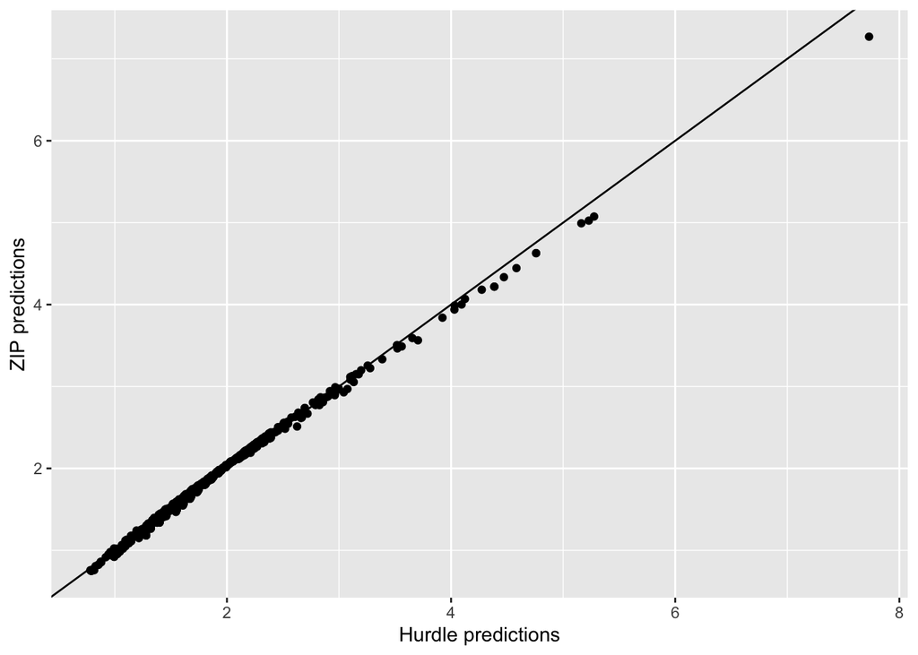

```r
tibble(fitted_h = fitted(modh),
       fitted_z = fitted(modz)) %>%
  ggplot() +
  geom_point(mapping = aes(x = fitted_h, y = fitted_z)) +
  geom_abline(intercept = 0, slope = 1) +
  labs(x = "Hurdle predictions", y = "ZIP predictions")
```

- We can use likelihood ratio (LRT) test to compare nested models. Consider a simplied model, where the Poisson model uses predictors `fem`, `kid5`, and `ment` and the Bernoulli model uses predictor `ment`.

```r
modz2 <- zeroinfl(art ~ fem + kid5 + ment | ment, data = bioChemists)
summary(modz2)
```

```
Call:
zeroinfl(formula = art ~ fem + kid5 + ment | ment, data = bioChemists)

Pearson residuals:
    Min      1Q  Median      3Q     Max
-2.2802 -0.8807 -0.2718  0.5131  7.4788

Count model coefficients (poisson with log link):
             Estimate Std. Error z value Pr(>|z|)
(Intercept)  0.694517   0.053025  13.098  < 2e-16 ***
femWomen    -0.233857   0.058400  -4.004 6.22e-05 ***
kid5        -0.126516   0.039668  -3.189  0.00143 **
ment         0.018004   0.002224   8.096 5.67e-16 ***

Zero-inflation model coefficients (binomial with logit link):
            Estimate Std. Error z value Pr(>|z|)
(Intercept) -0.68488    0.20529  -3.336 0.000849 ***
ment        -0.12680    0.03981  -3.185 0.001448 **
---
Signif. codes:  0 '***' 0.001 '**' 0.01 '*' 0.05 '.' 0.1 ' ' 1

Number of iterations in BFGS optimization: 13
Log-likelihood: -1608 on 6 Df
```

The LRT yields a large p-value, indicating the smaller model is justifiable.

```r
lrt <- 2 * (modz$loglik - modz2$loglik)
pchisq(lrt, 6, lower.tail = FALSE)
```

```
[1] 0.4041153
```

- Interpretation

```r
exp(coef(modz2))
```

```
count_(Intercept)    count_femWomen        count_kid5        count_ment
        2.0027412         0.7914748         0.8811604         1.0181669
 zero_(Intercept)         zero_ment
        0.5041522         0.8809082
```

- Prediction. For a single male with no children whose mentor procuded six articles, we predict that the chance he produces no articles is 0.278.

```r
tibble(fem = "Men", mar = "Single", kid5 = 0, ment = 6) %>%
  predict(modz2, newdata = ., type = "prob")
```

```
          0         1       2         3          4          5          6
1 0.2775879 0.1939403 0.21636 0.1609142 0.08975799 0.04005363 0.01489462
            7           8            9           10           11           12
1 0.004747556 0.001324094 0.0003282578 7.324092e-05 1.485593e-05 2.762214e-06
            13           14           15           16          17           18
1 4.740812e-07 7.555505e-08 1.123857e-08 1.567219e-09 2.05693e-10 2.549681e-11
            19
1 2.994132e-12
```

The zero part of model contributes 0.191 and the Poisson part contributes 0.087.

```r
tibble(fem = "Men", mar = "Single", kid5 = 0, ment = 6) %>%
  predict(modz2, newdata = ., type = "zero")
```

```
       1
0.190666
```